# NYC Covid-19 Data

We wish to do an initial analysis of some of the data which has been released for NYC. Then, we can extend this an fit a simple model for the spread of an infectious disease to both NYC and the entire US.

```r
library(tidyverse)
library(sf)
library(tidycensus)
theme_set(theme_classic())
```

# Exploratory Analysis

Read in the Covid-19 data along with the ACS data.

```r
link <- "https://raw.githubusercontent.com/nychealth/coronavirus-data/master/tests-by-zcta.csv"
nyc_zip <- read_csv(link)
nyc_zip %>% head()
```

| MODZCTA | Positive | Total | zcta_cum.perc_pos |
| --- | --- | --- | --- |
| NA | 1607 | 1917 | 83.83 |
| 10001 | 311 | 878 | 35.42 |
| 10002 | 878 | 2069 | 42.44 |
| 10003 | 399 | 1251 | 31.89 |
| 10004 | 28 | 87 | 32.18 |
| 10005 | 54 | 214 | 25.23 |

It would be nice to plot this at a zip code level. To do this we can download a shapefile of NYC and join it with the Covid data.

```r
zip_sf <- read_sf("C:/Users/owenw/Google Drive/GeneralStuff/Covid19/ZIP_CODE_040114/ZIP_CODE_040114.shp")
zip_sf
```

| ZIPCODE | BLDGZIP | PO_NAME | POPULATION | AREA | STATE | COUNTY | ST_FIPS | CTY_FIPS | URL | SHAPE_AREA | SHAPE_LEN | geometry |
| --- | --- | --- | --- | --- | --- | --- | --- | --- | --- | --- | --- | --- |
| 11436 | 0 | Jamaica | 18681 | 2.269930e+07 | NY | Queens | 36 | 081 | http://www.usps.com/ | 0 | 0 |  |
| 11213 | 0 | Brooklyn | 62426 | 2.963100e+07 | NY | Kings | 36 | 047 | http://www.usps.com/ | 0 | 0 |  |
| 11212 | 0 | Brooklyn | 83866 | 4.197210e+07 | NY | Kings | 36 | 047 | http://www.usps.com/ | 0 | 0 |  |
| 11225 | 0 | Brooklyn | 56527 | 2.369863e+07 | NY | Kings | 36 | 047 | http://www.usps.com/ | 0 | 0 |  |
| 11218 | 0 | Brooklyn | 72280 | 3.686880e+07 | NY | Kings | 36 | 047 | http://www.usps.com/ | 0 | 0 |  |
| 11226 | 0 | Brooklyn | 106132 | 3.940860e+07 | NY | Kings | 36 | 047 | http://www.usps.com/ | 0 | 0 |  |
| 11219 | 0 | Brooklyn | 92561 | 4.200274e+07 | NY | Kings | 36 | 047 | http://www.usps.com/ | 0 | 0 |  |
| 11210 | 0 | Brooklyn | 67067 | 4.788702e+07 | NY | Kings | 36 | 047 | http://www.usps.com/ | 0 | 0 |  |
| 11230 | 0 | Brooklyn | 80857 | 4.992670e+07 | NY | Kings | 36 | 047 | http://www.usps.com/ | 0 | 0 |  |
| 11204 | 0 | Brooklyn | 77354 | 4.355518e+07 | NY | Kings | 36 | 047 | http://www.usps.com/ | 0 | 0 |  |

[output cut: 253 more lines]

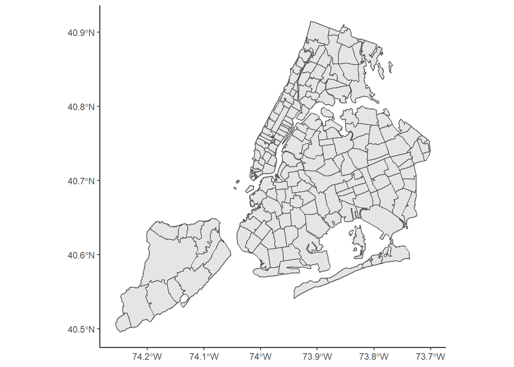

```r
ggplot(data = zip_sf) + geom_sf()
```

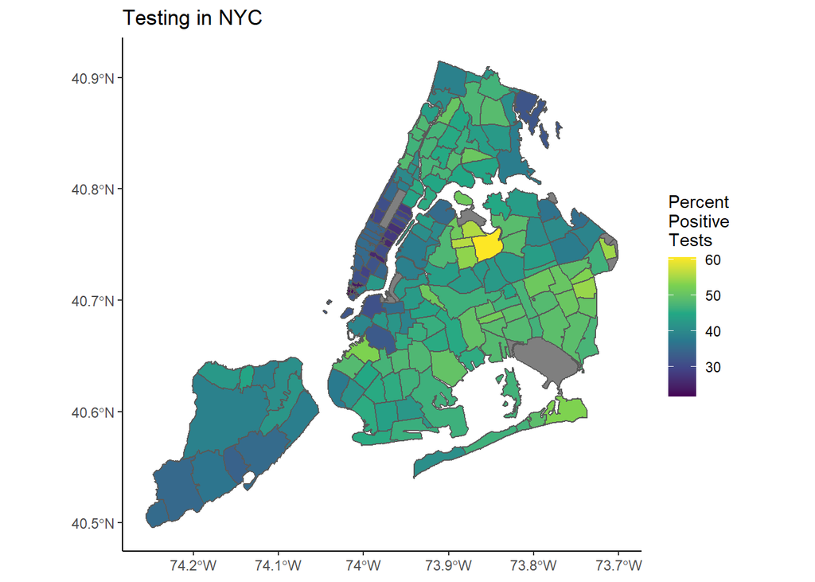

```r
sf_zip_data <- tibble(zip = zip_sf$ZIPCODE)
sf_zip_data <- sf_zip_data %>% mutate(zip = as.numeric(zip)) %>%
  left_join(nyc_zip, by = c(zip="MODZCTA"))

zip_sf$Covid <- sf_zip_data %>% select(Positive,Total,zcta_cum.perc_pos)


ggplot(data = zip_sf) + geom_sf(aes(fill=Covid$zcta_cum.perc_pos)) +
  scale_fill_continuous(type="viridis",name = "Percent \nPositive \nTests") + ggtitle("Testing in NYC")
```

```r
#+ ggmap::theme_nothing()
```

We had to download a different file and read it in to create this plot. It would be nice to not have to read an external file. Similarly, it might be interesting to compare this data to other demographic data which is observed at zip code level, such as income.

Zip codes can have very different numbers of people in them and Similarly, we have ACS data which also contains more granular information. Let’s use the `tidycensus` package to access this.

```r
#census_api_key("your_api_key",install=TRUE)
options(tigris_use_cache = TRUE)
acs_2018 <- get_acs(geography = "zcta",
                    variables = c(medincome = "B19013_001"),
                    year = 2018,geometry = TRUE)
acs_2018 %>% head()
```

|  | GEOID | NAME | variable | estimate | moe | geometry |
| --- | --- | --- | --- | --- | --- | --- |
| 1 | 00601 | ZCTA5 00601 | medincome | 13092 | 1049 |  |
| 2 | 00602 | ZCTA5 00602 | medincome | 16358 | 1082 |  |
| 3 | 00603 | ZCTA5 00603 | medincome | 16603 | 963 |  |
| 4 | 00606 | ZCTA5 00606 | medincome | 12832 | 2393 |  |
| 5 | 00610 | ZCTA5 00610 | medincome | 19309 | 1555 |  |
| 6 | 00612 | ZCTA5 00612 | medincome | 18171 | 944 |  |

```r
acs_2018 %>% dim()
```

```
## [1] 33120     6
```

```r
# to get a specific zip code
acs_2018 %>% filter(GEOID == "10025")
```

|  | GEOID | NAME | variable | estimate | moe | geometry |
| --- | --- | --- | --- | --- | --- | --- |
| 1 | 10025 | ZCTA5 10025 | medincome | 85930 | 6789 |  |

```r
acs_2018 <- acs_2018 %>% mutate(zip = as.numeric(GEOID))
nyc_zip %>% head()
```

| MODZCTA | Positive | Total | zcta_cum.perc_pos |
| --- | --- | --- | --- |
| NA | 1607 | 1917 | 83.83 |
| 10001 | 311 | 878 | 35.42 |
| 10002 | 878 | 2069 | 42.44 |
| 10003 | 399 | 1251 | 31.89 |
| 10004 | 28 | 87 | 32.18 |
| 10005 | 54 | 214 | 25.23 |

[figure not shown]

```r
nyc_zip %>% left_join(acs_2018 , by = c("MODZCTA"="zip")) %>%
  #select(estimate)
  ggplot(aes(estimate,Total)) + geom_point() +
  xlab("Median Household Income") +ylab("Positive Tests")
```

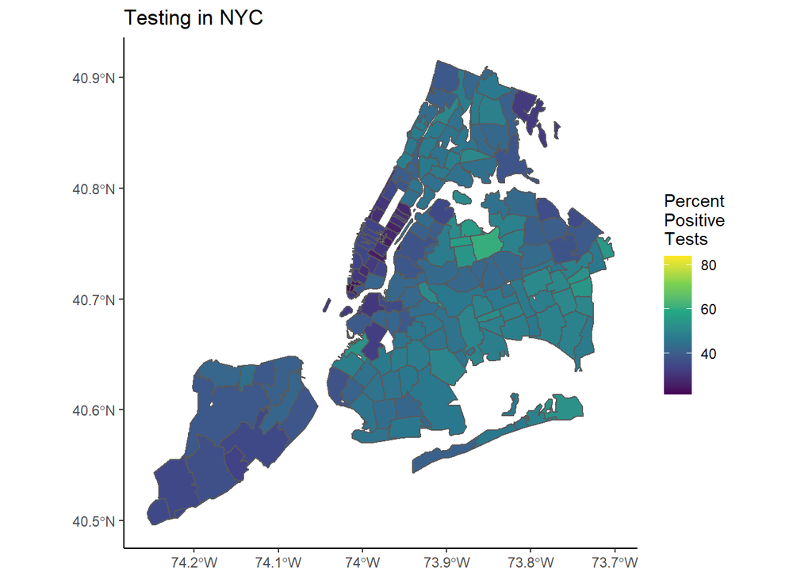

```r
# we can also use the census data to recreate the
# initial plot

# note we are using a right join now.

acs_2018 %>% right_join(nyc_zip , by = c("zip"="MODZCTA")) %>%
  #select(estimate)
  ggplot() +
  geom_sf(aes(fill=zcta_cum.perc_pos)) +
  scale_fill_continuous(type="viridis",name = "Percent \nPositive \nTests") + ggtitle("Testing in NYC")
```

This `tidycensus` package is extremely useful for vizualising and analysing demographic data across the US. For example, this is how easy it is to plot median income by state.

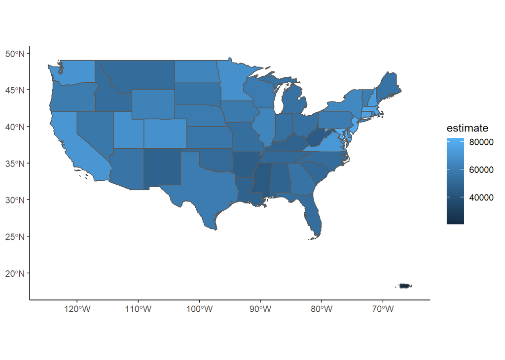

```r
acs_state <- get_acs(geography = "state",
                     variables = c(medincome = "B19013_001"),
                     year = 2018,geometry = TRUE)
acs_state %>% filter((NAME %in% c("Alaska","Hawaii"))==FALSE) %>%
  ggplot() + geom_sf(aes(fill=estimate))
```

We can also do this at a much more granular level.

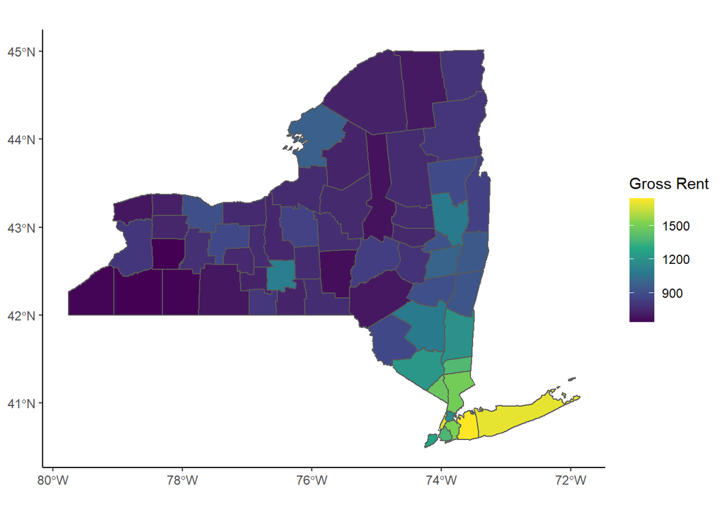

```r
ny_rent <- get_acs(geography = "county",
              variables = c(med_gross_rent = "B25064_001"),
              state = "NY",
              geometry = TRUE,
              year = 2018)
ny_rent %>% ggplot() + geom_sf(aes(fill=estimate)) +
  scale_fill_continuous(type = "viridis",name = "Gross Rent")
```

Lets go back to looking at the NYC Covid data. We could extract lots of other variables for each zip code.

One important point is that zip codes vary a lot and to compare them directly is a bad idea. The number of people living in a zipcode can vary hugely. One simple way to correct for this would be to compute the number of positive tests with respect to this, for example the number of positive tests per 1000 people.

We can extract the population of each zip code also.

```r
acs_2018_detailed <- get_acs(geography = "zcta",
                             variables = c(medincome =
                                             "B19013_001",
                                           pop = "B01003_001",
                                           med_age =
                                             "B01002_001"
                                           ),
                    year = 2018,geometry = FALSE)
acs_variables <- acs_2018_detailed %>% pivot_wider(id_cols = c(GEOID,NAME),names_from = variable,
                                  values_from = estimate )
```

Then we want to combine the variables, the shape information and the Covid information.

```r
nyc <- acs_2018 %>%
  right_join(nyc_zip , by = c("zip"="MODZCTA")) %>%
  select(-c(variable,estimate,moe))

nyc <- nyc %>% left_join(acs_variables,by = "GEOID")

nyc %>% head()
```

|  | GEOID | NAME.x | zip | Positive | Total | zcta_cum.perc_pos | NAME.y | medincome | pop | med_age | geometry |
| --- | --- | --- | --- | --- | --- | --- | --- | --- | --- | --- | --- |
| 1 | NA | NA | NA | 1607 | 1917 | 83.83 | NA | NA | NA | NA |  |
| 2 | 10001 | ZCTA5 10001 | 10001 | 311 | 878 | 35.42 | ZCTA5 10001 | 88526 | 22924 | 36.7 |  |
| 3 | 10002 | ZCTA5 10002 | 10002 | 878 | 2069 | 42.44 | ZCTA5 10002 | 35859 | 74993 | 43.6 |  |
| 4 | 10003 | ZCTA5 10003 | 10003 | 399 | 1251 | 31.89 | ZCTA5 10003 | 112131 | 54682 | 32.3 |  |
| 5 | 10004 | ZCTA5 10004 | 10004 | 28 | 87 | 32.18 | ZCTA5 10004 | 157645 | 3028 | 37.1 |  |
| 6 | 10005 | ZCTA5 10005 | 10005 | 54 | 214 | 25.23 | ZCTA5 10005 | 173333 | 8831 | 30.1 |  |

Next we want to correct for population to better represent the underlying data. To do this we want to re-express the number of tests and the number of positive tests in terms of population. One way to do this is to compute the number of (positive) tests per thousand people.

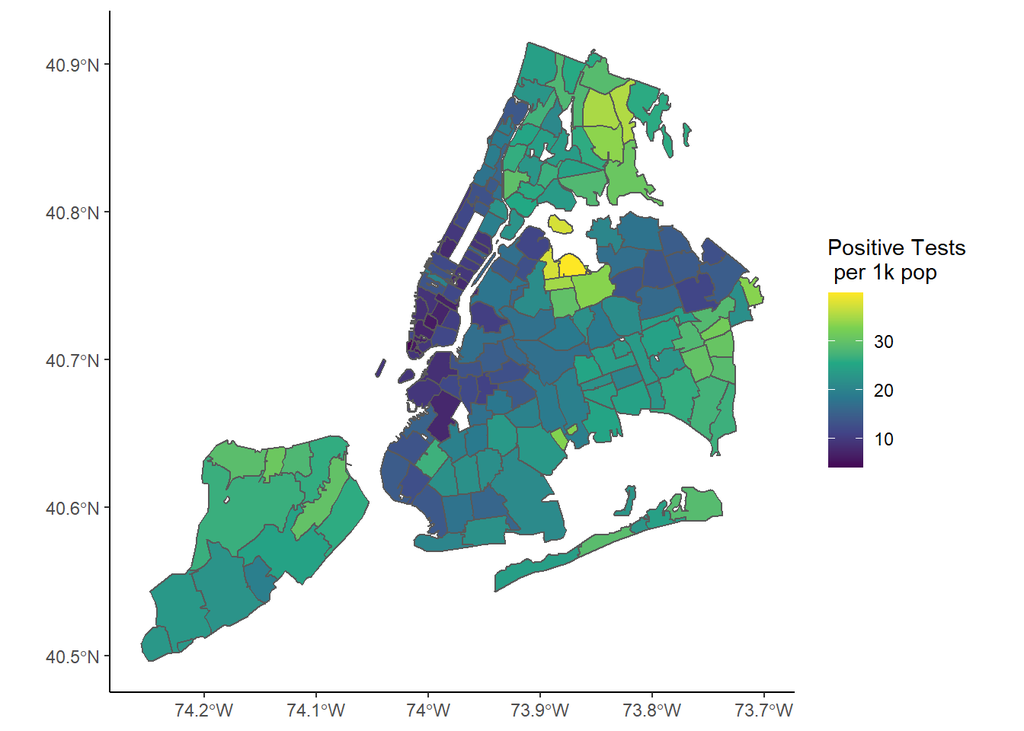

```r
nyc_sf <- nyc %>%
  mutate(pop_1000 = pop/1000,
         test_1000 = Total/pop_1000,
         positive_1000 = Positive/pop_1000)


ggplot(nyc_sf) + geom_sf(aes(fill=positive_1000)) +
  scale_fill_continuous(type = "viridis",name = "Positive Tests\n per 1k pop")
```

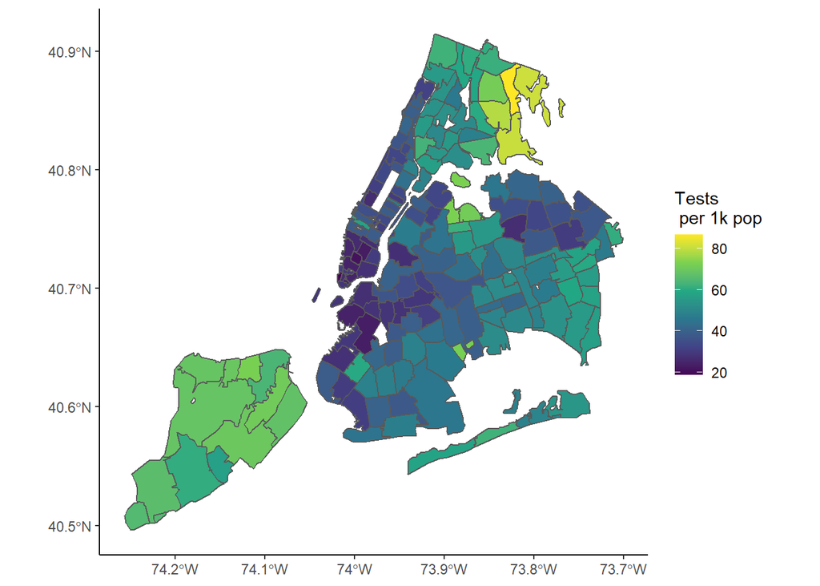

```r
ggplot(nyc_sf) + geom_sf(aes(fill=test_1000)) +
  scale_fill_continuous(type = "viridis",name = "Tests\n per 1k pop")
```

Now we can investigate relationships between the number of positive tests (per 1000 population) and demographic factors. These should be more “correct”.

The first thing we can investigate is the relationship between income and the number of tests.

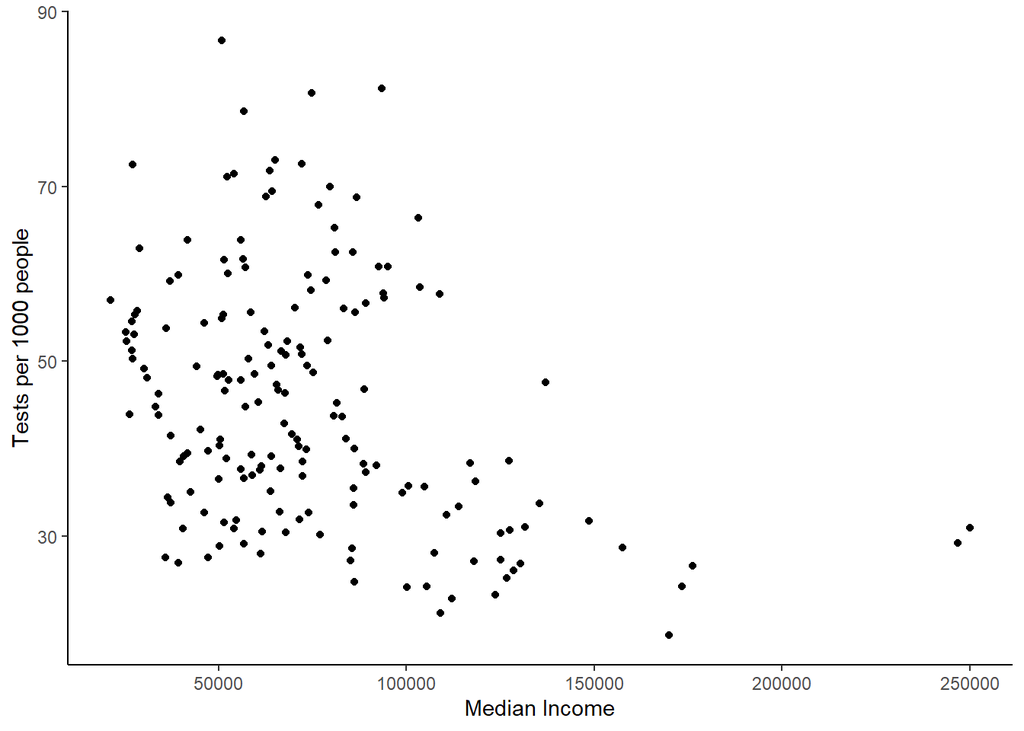

```r
nyc_sf %>% ggplot(aes(medincome,test_1000)) +
  geom_point() + theme_classic() + xlab("Median Income") +
  ylab("Tests per 1000 people")
```

Similarly, we can look at the relationship between income and the number of positive tests.

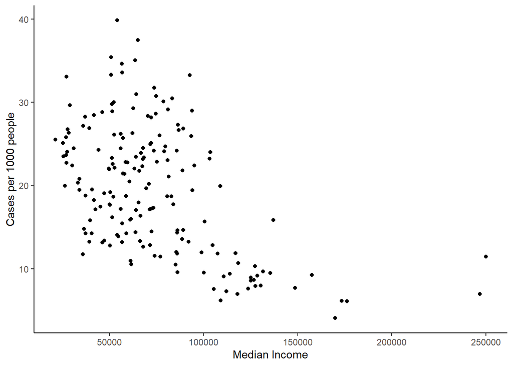

```r
nyc_sf %>% ggplot(aes(medincome,positive_1000)) +
  geom_point() + theme_classic() + xlab("Median Income") +
  ylab("Cases per 1000 people")
```

There seems to be a similar relationship.

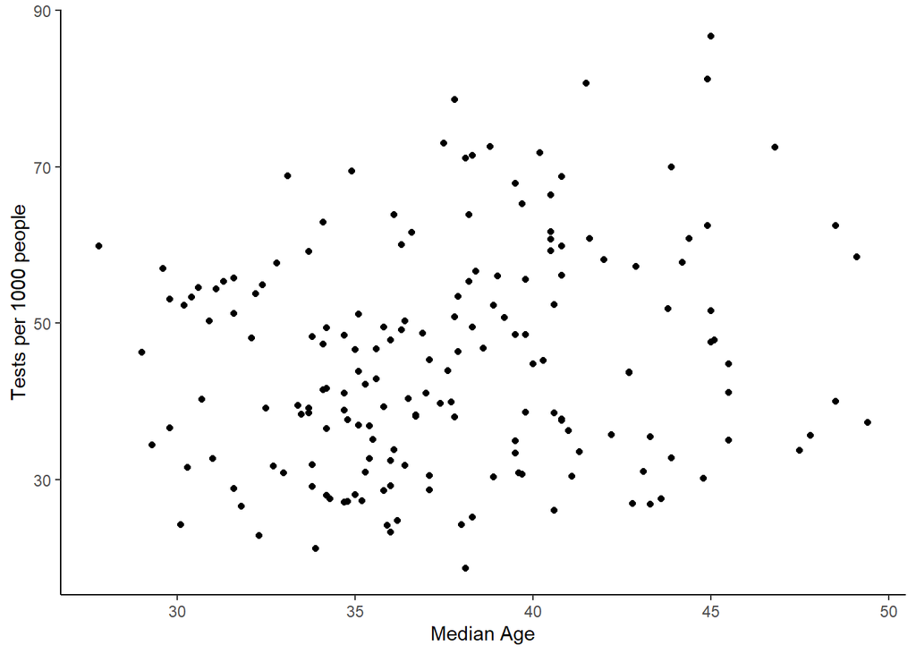

```r
nyc_sf %>% ggplot(aes(med_age,test_1000)) +
  geom_point() + theme_classic() + xlab("Median Age") +
  ylab("Tests per 1000 people")
```

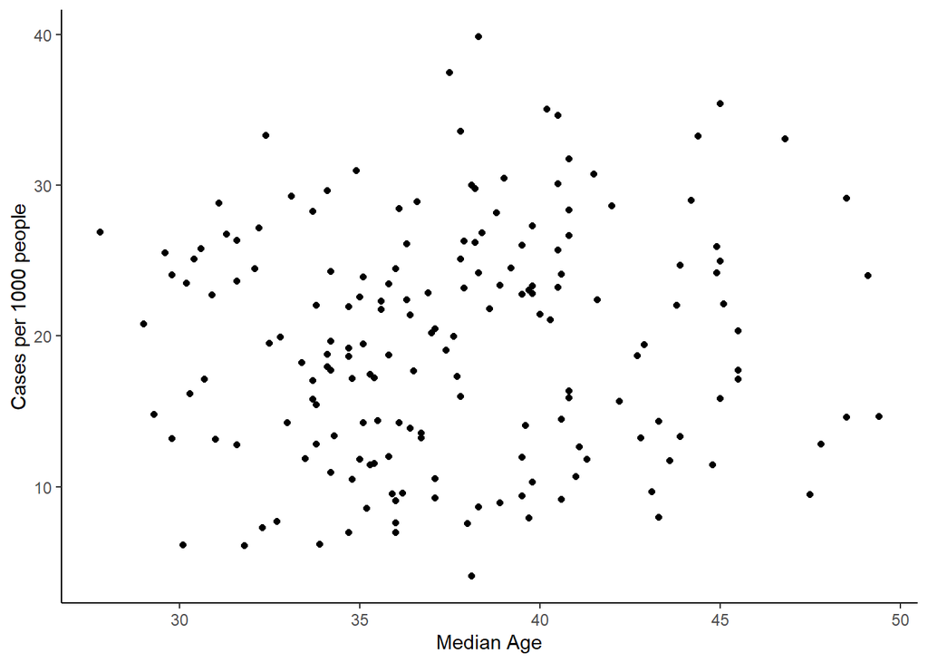

```r
nyc_sf %>% ggplot(aes(med_age,positive_1000)) +
  geom_point() + theme_classic() + xlab("Median Age") +
  ylab("Cases per 1000 people")
```

We can try fit a linear regression using these demographic variables.

```r
model_1 <- lm(test_1000~med_age+medincome,data = nyc_sf)
summary(model_1)
```

```
##
## Call:
## lm(formula = test_1000 ~ med_age + medincome, data = nyc_sf)
##
## Residuals:
##     Min      1Q  Median      3Q     Max
## -28.762  -9.575  -1.004   8.631  33.131
##
## Coefficients:
##               Estimate Std. Error t value Pr(>|t|)
## (Intercept)  2.642e+01  7.884e+00   3.351 0.000987 ***
## med_age      8.203e-01  2.138e-01   3.838 0.000174 ***
## medincome   -1.627e-04  2.714e-05  -5.995 1.14e-08 ***
## ---
## Signif. codes:  0 '***' 0.001 '**' 0.01 '*' 0.05 '.' 0.1 ' ' 1
##
## Residual standard error: 12.8 on 174 degrees of freedom
##   (1 observation deleted due to missingness)
## Multiple R-squared:  0.1956, Adjusted R-squared:  0.1863
## F-statistic: 21.15 on 2 and 174 DF,  p-value: 5.988e-09
```

```r
model_2 <- lm(positive_1000~med_age+medincome,data = nyc_sf)
summary(model_2)
```

```
##
## Call:
## lm(formula = positive_1000 ~ med_age + medincome, data = nyc_sf)
##
## Residuals:
##      Min       1Q   Median       3Q      Max
## -14.3720  -5.2426  -0.4715   4.1567  17.7630
##
## Coefficients:
##               Estimate Std. Error t value Pr(>|t|)
## (Intercept)  1.539e+01  3.932e+00   3.914  0.00013 ***
## med_age      3.427e-01  1.066e-01   3.215  0.00155 **
## medincome   -1.185e-04  1.353e-05  -8.759 1.71e-15 ***
## ---
## Signif. codes:  0 '***' 0.001 '**' 0.01 '*' 0.05 '.' 0.1 ' ' 1
##
## Residual standard error: 6.383 on 174 degrees of freedom
##   (1 observation deleted due to missingness)
## Multiple R-squared:  0.3101, Adjusted R-squared:  0.3022
## F-statistic: 39.11 on 2 and 174 DF,  p-value: 9.394e-15
```

# A Simple SIR Model for NYC

One of the common ways that infectious diseases are modeled is using a SIR model. The population is divided into three groups at a given time:

- Susceptible - people who could get infected
- Infected - people who are currently infected
- Recovered - people who have had the disease and have recovered.

We want to model $C(t)$, the accumulated total cases at time $t$. We can do this using a logistic model, which gives a differential equation of the form

$$\frac{dC(t)}{dt} = r C(t)\left[ 1- \frac{C(t)}{K} \right],$$
where $r$ is the infection rate and $K$ is the final size of the epidemic. Intuitively, this says that the rate of change of the total number of cases depends on the current cases, the infection rate, and how many more people can get infected. As $C(t)$ grows close to $K$, this rate has to slow down.

The solution to this differential equation is given by

$$C(t) = \frac{K C_0}{C_0 +(K-C_0)\exp(-rt)}.$$
Here $C_0$ is the number of cases at $t=0$, some starting point. We want to estimate $K$ and $r$ here for NYC currently.

We need to use data which gives the number of cases each day. Thankfully, this is also available onlne.

```r
link_cases <- "https://raw.githubusercontent.com/nychealth/coronavirus-data/master/case-hosp-death.csv"
nyc_cases <- read_csv(link_cases)
nyc_cases %>% head()
```

| DATE_OF_INTEREST | CASE_COUNT | HOSPITALIZED_COUNT | DEATH_COUNT |
| --- | --- | --- | --- |
| 3/3/20 | 2 | 7 | NA |
| 3/4/20 | 5 | 8 | NA |
| 3/5/20 | 3 | 13 | NA |
| 3/6/20 | 7 | 12 | NA |
| 3/7/20 | 7 | 10 | NA |
| 3/8/20 | 21 | 14 | NA |

```r
nyc_cases$TIME <- c(0:(nrow(nyc_cases)-1))

nyc_time_data <- nyc_cases %>%
  mutate(DATE_OF_INTEREST =
           as.Date(format(as.Date(DATE_OF_INTEREST,
                                    format= "%m/%d/%Y"),
                                   "20%y-%m-%d")),
         CUMUL_CASES = cumsum(CASE_COUNT)) %>%
  select(DATE_OF_INTEREST,TIME,CUMUL_CASES)
```

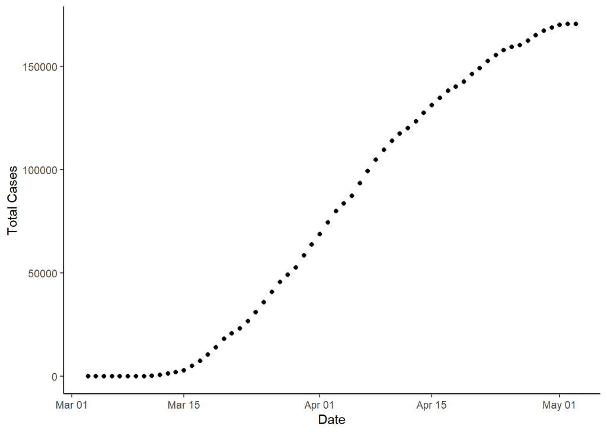

```r
nyc_time_data %>% ggplot(aes(DATE_OF_INTEREST,CUMUL_CASES)) +
  geom_point() + theme_classic() + xlab("Date") +
  ylab("Total Cases")
```

```r
logistic_model <- function(data) {
  data <- data %>% arrange(TIME)
  C_0 <- data$CUMUL_CASES[1]
  C_max <- data$CUMUL_CASES[nrow(data)]
  fit <-nls(
    formula = CUMUL_CASES ~ K / (1 + ((K - C_0) / C_0) * exp(-R * TIME)),
    data = data,
    start = list(K = 2 * C_max, R = 0.5),
    control = nls.control(minFactor = 1e-6, maxiter = 100)
  )
  return(fit)
}

fit_log<- logistic_model(nyc_time_data)

summary(fit_log)
```

```
##
## Formula: CUMUL_CASES ~ K/(1 + ((K - C_0)/C_0) * exp(-R * TIME))
##
## Parameters:
##    Estimate Std. Error t value Pr(>|t|)
## K 1.459e+05  3.570e+03   40.86   <2e-16 ***
## R 3.690e-01  6.111e-03   60.39   <2e-16 ***
## ---
## Signif. codes:  0 '***' 0.001 '**' 0.01 '*' 0.05 '.' 0.1 ' ' 1
##
## Residual standard error: 17450 on 60 degrees of freedom
##
## Number of iterations to convergence: 20
## Achieved convergence tolerance: 7.921e-06
```

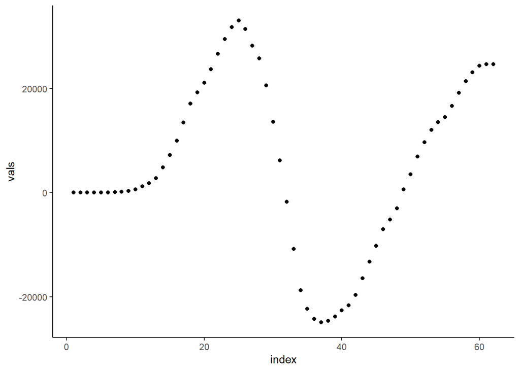

```r
log_model_fit <- summary(fit_log)

resid <- tibble(index = 1:nrow(nyc_cases),
                vals = log_model_fit$residuals)

ggplot(resid,aes(index,vals)) + geom_point() +
  theme_classic()
```

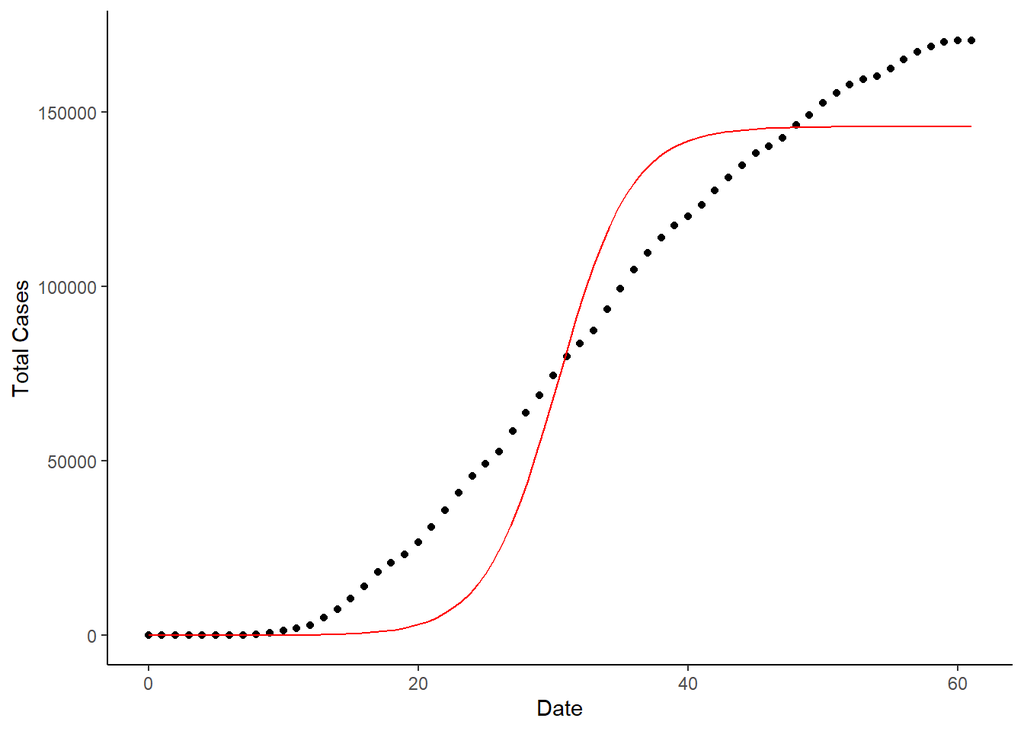

```r
K_est <- coefficients(fit_log)[1]
r_est <- coefficients(fit_log)[2]
C_0 <- 2

nyc_time_data %>% ggplot(aes(TIME,CUMUL_CASES)) +
  geom_point() + theme_classic() + xlab("Date") +
  ylab("Total Cases") +
  stat_function(fun = function(TIME)
     K_est / (1 + ((K_est - C_0) / C_0) *exp(-r_est * TIME)),
     colour = "red"
    )
```

So this model is not working particularly well. It is struggling to correctly capture the spread. There are many possible reasons for this.

- The starting point. We are using the first day in this data set. Try changing this and see what happens.
- NYC is so closely connected to the other regions around it in terms of people working in the city, etc. This model might work better on a country level.
- A more flexible model would better model this. There are many extensions such as the SEIR, SIRD, and SEIS models.

# The same model for the US

We can fit this type of model for the US instead.

Johns Hopkins also makes this data available online.

```r
us_data <- "https://raw.githubusercontent.com/CSSEGISandData/COVID-19/master/csse_covid_19_data/csse_covid_19_time_series/time_series_covid19_confirmed_US.csv"
us_cases <- read_csv(us_data)
us_cases %>% head()
```

| UID | iso2 | iso3 | code3 | FIPS | Admin2 | Province_State | Country_Region | Lat | Long_ | Combined_Key | 1/22/20 | 1/23/20 | 1/24/20 | 1/25/20 | 1/26/20 | 1/27/20 | 1/28/20 | 1/29/20 | 1/30/20 | 1/31/20 | 2/1/20 | 2/2/20 | 2/3/20 | 2/4/20 | 2/5/20 | 2/6/20 | 2/7/20 | 2/8/20 | 2/9/20 | … |
| --- | --- | --- | --- | --- | --- | --- | --- | --- | --- | --- | --- | --- | --- | --- | --- | --- | --- | --- | --- | --- | --- | --- | --- | --- | --- | --- | --- | --- | --- | --- |
| 16 | AS | ASM | 16 | 60 | NA | American Samoa | US | -14.27100 | -170.13200 | American Samoa, US | 0 | 0 | 0 | 0 | 0 | 0 | 0 | 0 | 0 | 0 | 0 | 0 | 0 | 0 | 0 | 0 | 0 | 0 | 0 | … |
| 316 | GU | GUM | 316 | 66 | NA | Guam | US | 13.44430 | 144.79370 | Guam, US | 0 | 0 | 0 | 0 | 0 | 0 | 0 | 0 | 0 | 0 | 0 | 0 | 0 | 0 | 0 | 0 | 0 | 0 | 0 | … |
| 580 | MP | MNP | 580 | 69 | NA | Northern Mariana Islands | US | 15.09790 | 145.67390 | Northern Mariana Islands, US | 0 | 0 | 0 | 0 | 0 | 0 | 0 | 0 | 0 | 0 | 0 | 0 | 0 | 0 | 0 | 0 | 0 | 0 | 0 | … |
| 630 | PR | PRI | 630 | 72 | NA | Puerto Rico | US | 18.22080 | -66.59010 | Puerto Rico, US | 0 | 0 | 0 | 0 | 0 | 0 | 0 | 0 | 0 | 0 | 0 | 0 | 0 | 0 | 0 | 0 | 0 | 0 | 0 | … |
| 850 | VI | VIR | 850 | 78 | NA | Virgin Islands | US | 18.33580 | -64.89630 | Virgin Islands, US | 0 | 0 | 0 | 0 | 0 | 0 | 0 | 0 | 0 | 0 | 0 | 0 | 0 | 0 | 0 | 0 | 0 | 0 | 0 | … |
| 84001001 | US | USA | 840 | 1001 | Autauga | Alabama | US | 32.53953 | -86.64408 | Autauga, Alabama, US | 0 | 0 | 0 | 0 | 0 | 0 | 0 | 0 | 0 | 0 | 0 | 0 | 0 | 0 | 0 | 0 | 0 | 0 | 0 | … |

```r
colnames(us_cases)
```

```
##   [1] "UID"            "iso2"           "iso3"           "code3"
##   [5] "FIPS"           "Admin2"         "Province_State" "Country_Region"
##   [9] "Lat"            "Long_"          "Combined_Key"   "1/22/20"
##  [13] "1/23/20"        "1/24/20"        "1/25/20"        "1/26/20"
##  [17] "1/27/20"        "1/28/20"        "1/29/20"        "1/30/20"
##  [21] "1/31/20"        "2/1/20"         "2/2/20"         "2/3/20"
##  [25] "2/4/20"         "2/5/20"         "2/6/20"         "2/7/20"
##  [29] "2/8/20"         "2/9/20"         "2/10/20"        "2/11/20"
##  [33] "2/12/20"        "2/13/20"        "2/14/20"        "2/15/20"
##  [37] "2/16/20"        "2/17/20"        "2/18/20"        "2/19/20"
##  [41] "2/20/20"        "2/21/20"        "2/22/20"        "2/23/20"
##  [45] "2/24/20"        "2/25/20"        "2/26/20"        "2/27/20"
##  [49] "2/28/20"        "2/29/20"        "3/1/20"         "3/2/20"
##  [53] "3/3/20"         "3/4/20"         "3/5/20"         "3/6/20"
##  [57] "3/7/20"         "3/8/20"         "3/9/20"         "3/10/20"
##  [61] "3/11/20"        "3/12/20"        "3/13/20"        "3/14/20"
##  [65] "3/15/20"        "3/16/20"        "3/17/20"        "3/18/20"
##  [69] "3/19/20"        "3/20/20"        "3/21/20"        "3/22/20"
##  [73] "3/23/20"        "3/24/20"        "3/25/20"        "3/26/20"
##  [77] "3/27/20"        "3/28/20"        "3/29/20"        "3/30/20"
##  [81] "3/31/20"        "4/1/20"         "4/2/20"         "4/3/20"
##  [85] "4/4/20"         "4/5/20"         "4/6/20"         "4/7/20"
##  [89] "4/8/20"         "4/9/20"         "4/10/20"        "4/11/20"
##  [93] "4/12/20"        "4/13/20"        "4/14/20"        "4/15/20"
##  [97] "4/16/20"        "4/17/20"        "4/18/20"        "4/19/20"
## [101] "4/20/20"        "4/21/20"        "4/22/20"        "4/23/20"
## [105] "4/24/20"        "4/25/20"        "4/26/20"        "4/27/20"
## [109] "4/28/20"        "4/29/20"        "4/30/20"        "5/1/20"
## [113] "5/2/20"         "5/3/20"         "5/4/20"
```

We want to rearrange this data so that we can more easily fit our model to it.

Lets first fit the model to the entire US. This would allow us to estimate the total number of infections we will see, $K$.

```r
tidy_us <- us_cases %>% pivot_longer(cols = contains("/"),names_to = "Date",values_to = "Count") %>%
  mutate(Date = as.Date(format(as.Date(Date,
                                    format= "%m/%d/%Y"),
                                   "20%y-%m-%d"))) %>%
  select(Province_State,Date,Count)
```

```r
tidy_us %>% head()
```

| Province_State | Date | Count |
| --- | --- | --- |
| American Samoa | 2020-01-22 | 0 |
| American Samoa | 2020-01-23 | 0 |
| American Samoa | 2020-01-24 | 0 |
| American Samoa | 2020-01-25 | 0 |
| American Samoa | 2020-01-26 | 0 |
| American Samoa | 2020-01-27 | 0 |

```r
model_data <- tidy_us %>% group_by(Date) %>%
  summarise(Total = sum(Count)) %>%
  arrange(Date)

model_data %>% head()
```

| Date | Total |
| --- | --- |
| 2020-01-22 | 1 |
| 2020-01-23 | 1 |
| 2020-01-24 | 2 |
| 2020-01-25 | 2 |
| 2020-01-26 | 5 |
| 2020-01-27 | 5 |

```r
model_data$TIME <- 1:nrow(model_data)

model_data %>% tail(n=10)
```

| Date | Total | TIME |
| --- | --- | --- |
| 2020-04-25 | 938154 | 95 |
| 2020-04-26 | 965785 | 96 |
| 2020-04-27 | 988197 | 97 |
| 2020-04-28 | 1012582 | 98 |
| 2020-04-29 | 1039909 | 99 |
| 2020-04-30 | 1069424 | 100 |
| 2020-05-01 | 1103461 | 101 |
| 2020-05-02 | 1132539 | 102 |
| 2020-05-03 | 1158040 | 103 |
| 2020-05-04 | 1180375 | 104 |

This is now in a nice tidy format that we can use for the model we have up above.

```r
model_data$CUMUL_CASES = model_data$Total

fit_us<- logistic_model(model_data)

summary(fit_us)
```

```
##
## Formula: CUMUL_CASES ~ K/(1 + ((K - C_0)/C_0) * exp(-R * TIME))
##
## Parameters:
##    Estimate Std. Error t value Pr(>|t|)
## K 1.070e+06  1.322e+04   80.96   <2e-16 ***
## R 1.702e-01  5.424e-04  313.78   <2e-16 ***
## ---
## Signif. codes:  0 '***' 0.001 '**' 0.01 '*' 0.05 '.' 0.1 ' ' 1
##
## Residual standard error: 38510 on 102 degrees of freedom
##
## Number of iterations to convergence: 11
## Achieved convergence tolerance: 3.98e-06
```

So this gives an estimate for $R$ in the entire US of 0.170206 and a total number of cases of 1.069952310^{6}, which is currently less than the total number of cases. Lets look at the fit of this model.

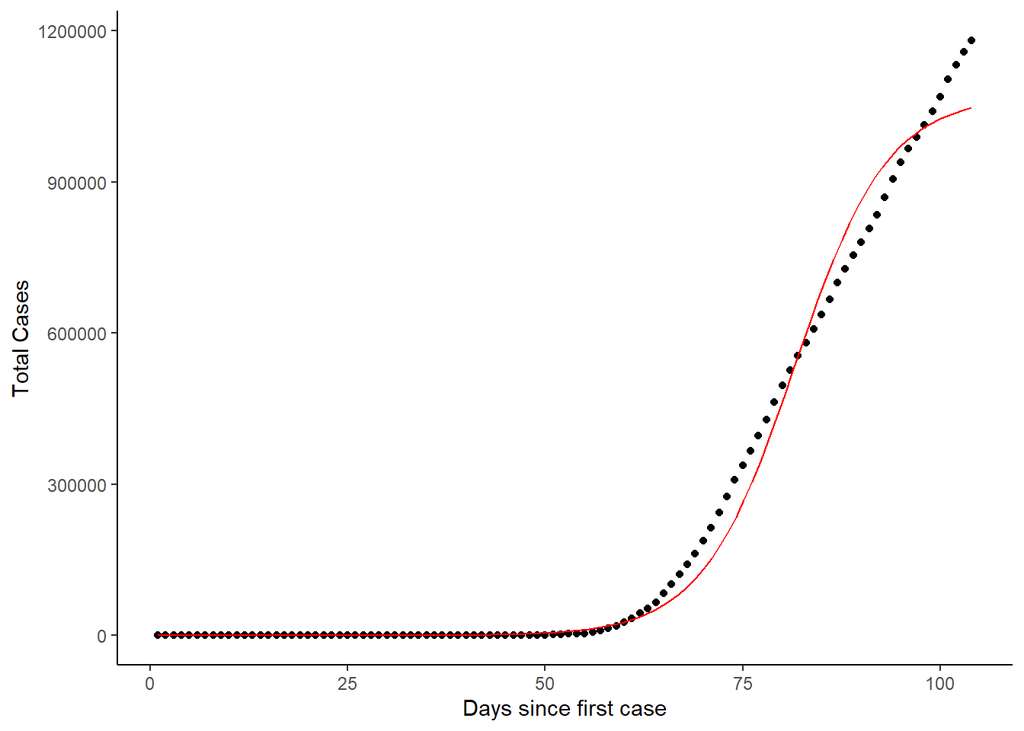

```r
K_est <- coefficients(fit_us)[1]
r_est <- coefficients(fit_us)[2]
C_0 <- 1



model_data %>% ggplot(aes(TIME,CUMUL_CASES)) +
  geom_point() + theme_classic()+
  ylab("Total Cases") +
  stat_function(fun = function(TIME)
     K_est / (1 + ((K_est - C_0) / C_0) *exp(-r_est * TIME)),
     colour = "red"
    ) +xlab("Days since first case")
```

So this fit is much better than what we got for NYC alone, which we can also see by looking at the residuals.

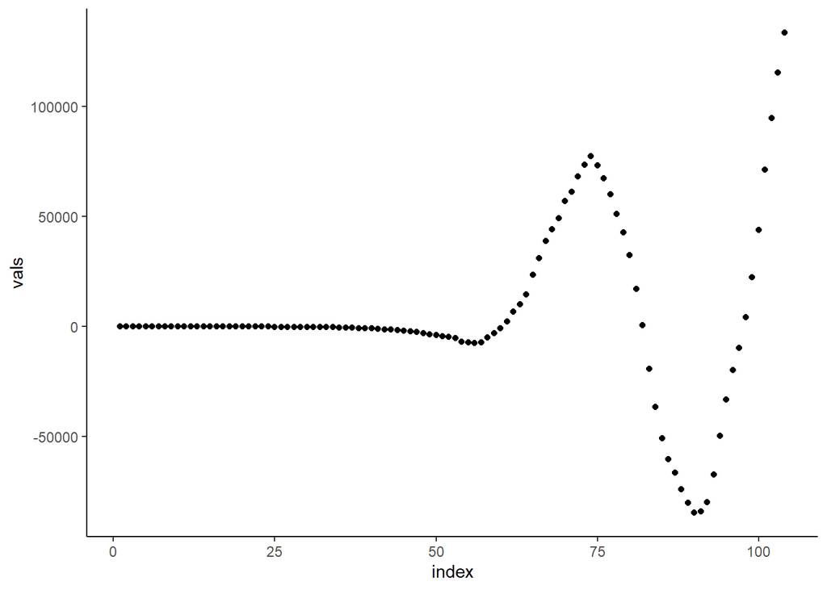

```r
us_model_fit <- summary(fit_us)

resid <- tibble(index = 1:nrow(model_data),
                vals = us_model_fit$residuals)

ggplot(resid,aes(index,vals)) + geom_point() +
  theme_classic()
```

So there is still some pretty obvious structure here that we would like to not have. But it is an improvement.